# 5.2. Settlements Exploratory Analysis

Alexander Sheludkov

26 11 2018

```r
library(dplyr)
library(tidyr)
library(ggplot2)
library(corrplot)
library(lme4)
library(stargazer)
```

```r
load(file = "data/Part3_res_dataset.Rdata")
```

## Research Q2: Как структурное положение н.п. в сети населенных пунктов влияло на динамику его населения?

Y в нашей модели - это отношение населения н.п. в 2010 году к населению в 2002: `pop2010to2002_rel`

### 1. Preprocessing

#### 1.1 Чистка данных

- Удалим населенные пункты, которые исчезли в результате поглощения городами
- Выделим из датаеста интересующие нас предикторы

```r
df %>%
  filter(!(pop2010to2002_rel == 0 & Census2002 > 1000 & MunicipalDistrict == "Тобольский район")) %>%
  filter(!(pop2010to2002_rel == 0 & MunicipalDistrict == "Тюменский район")) %>%
  dplyr:: select(pop2010to2002_rel, clust_6, clust_18, starts_with("clo"), starts_with("betw"), -ends_with("w")) ->
  df_cleaned
summary(df_cleaned)
```

```
##  pop2010to2002_rel    clust_6         clust_18           clo
##  Min.   :  0.00    Min.   :1.000   Min.   : 1.000   Min.   :1.304e-09
##  1st Qu.: 71.86    1st Qu.:2.000   1st Qu.: 6.000   1st Qu.:2.815e-09
##  Median : 86.85    Median :4.000   Median :10.000   Median :3.082e-09
##  Mean   : 85.07    Mean   :3.691   Mean   : 9.538   Mean   :3.088e-09
##  3rd Qu.: 98.86    3rd Qu.:5.000   3rd Qu.:13.000   3rd Qu.:3.384e-09
##  Max.   :513.79    Max.   :6.000   Max.   :18.000   Max.   :3.975e-09
##     clo_CL6             clo_CL18            betw_CL6
##  Min.   :9.199e-09   Min.   :4.590e-08   Min.   :    0.0
##  1st Qu.:3.427e-08   1st Qu.:1.487e-07   1st Qu.:  326.2
##  Median :4.208e-08   Median :2.383e-07   Median : 1646.0
##  Mean   :4.942e-08   Mean   :2.923e-07   Mean   : 2847.9
##  3rd Qu.:6.048e-08   3rd Qu.:3.694e-07   3rd Qu.: 4309.5
##  Max.   :1.330e-07   Max.   :1.467e-06   Max.   :21198.5
##    betw_CL18
##  Min.   :   0.0
##  1st Qu.:  92.5
##  Median : 363.0
##  Mean   : 566.5
##  3rd Qu.: 816.8
##  Max.   :4406.0
```

Проверка на выбросы

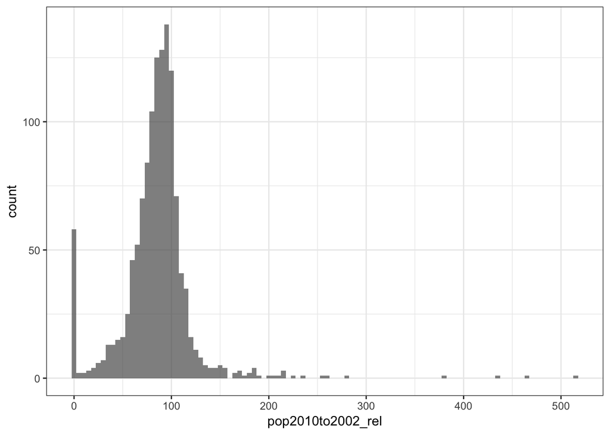

```r
df_cleaned %>%
  ggplot(aes(pop2010to2002_rel))+
  geom_histogram(alpha = 0.7, binwidth = 5)+
  theme_bw()
```

Распределение стремится к нормальному, но есть множество выбросов. Речь идет о небольших деревнях, где даже незначительные изменения в численности населения высокие в процентном выражении.We remove outliers beyond 3*Median Absolute Deviation.

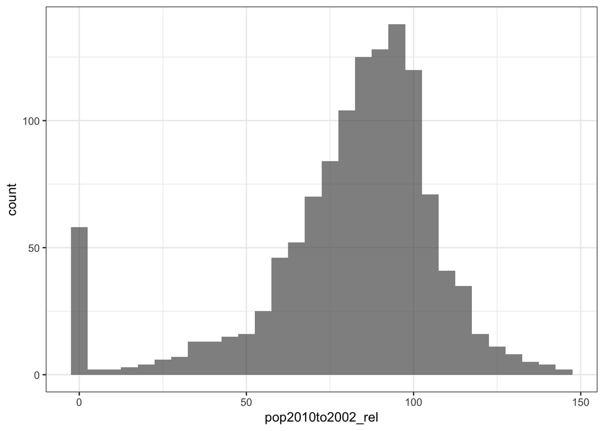

```r
df_cleaned %>%
  mutate(dev = pop2010to2002_rel - median(pop2010to2002_rel)) %>%
  filter(dev <= 3*mad(pop2010to2002_rel)) %>%
  select(-dev) -> df_cleaned

df_cleaned %>%
  ggplot(aes(pop2010to2002_rel))+
  geom_histogram(alpha = 0.7, binwidth = 5)+
  theme_bw()
```

```r
summary(df_cleaned)
```

```
##  pop2010to2002_rel    clust_6         clust_18           clo
##  Min.   :  0.00    Min.   :1.000   Min.   : 1.000   Min.   :1.304e-09
##  1st Qu.: 71.41    1st Qu.:2.000   1st Qu.: 6.000   1st Qu.:2.814e-09
##  Median : 85.99    Median :4.000   Median :10.000   Median :3.081e-09
##  Mean   : 81.02    Mean   :3.663   Mean   : 9.429   Mean   :3.090e-09
##  3rd Qu.: 97.84    3rd Qu.:5.000   3rd Qu.:13.000   3rd Qu.:3.395e-09
##  Max.   :142.86    Max.   :6.000   Max.   :18.000   Max.   :3.975e-09
##     clo_CL6             clo_CL18            betw_CL6
##  Min.   :9.199e-09   Min.   :4.590e-08   Min.   :    0.0
##  1st Qu.:3.441e-08   1st Qu.:1.474e-07   1st Qu.:  330.7
##  Median :4.226e-08   Median :2.358e-07   Median : 1685.5
##  Mean   :4.971e-08   Mean   :2.910e-07   Mean   : 2862.0
##  3rd Qu.:6.126e-08   3rd Qu.:3.683e-07   3rd Qu.: 4341.4
##  Max.   :1.330e-07   Max.   :1.467e-06   Max.   :21198.5
##    betw_CL18
##  Min.   :   0.00
##  1st Qu.:  90.88
##  Median : 363.00
##  Mean   : 563.91
##  3rd Qu.: 818.50
##  Max.   :4406.00
```

#### 1.2 Отбор предикторов и их трансформация

Проверим предикторы на корреляцию

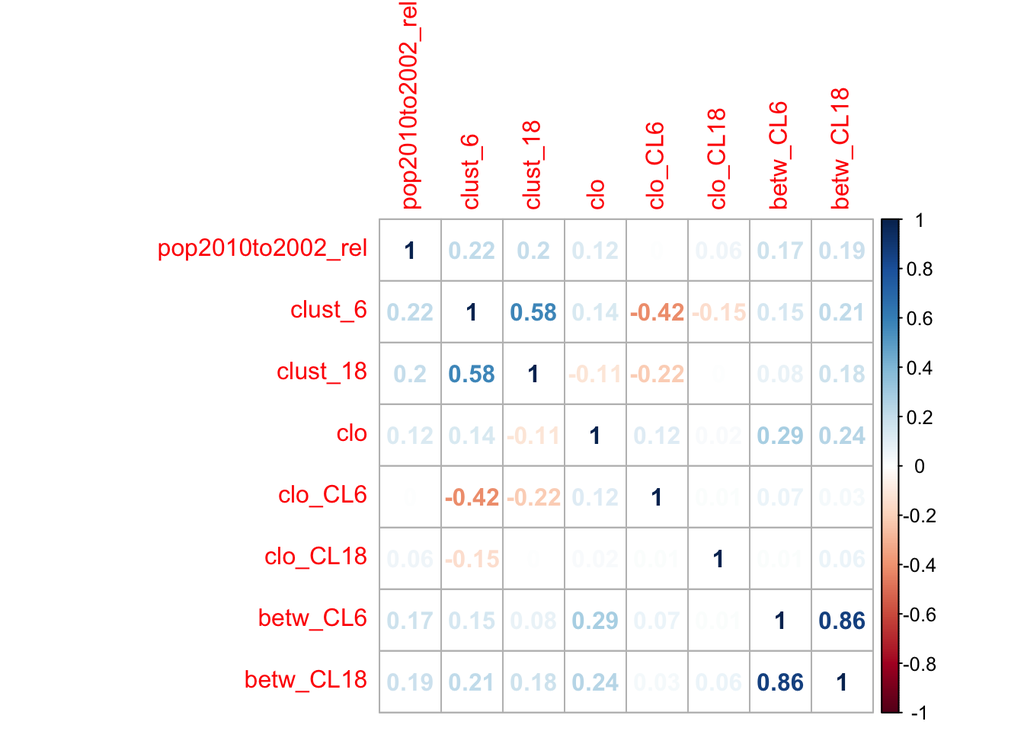

```r
corr <- cor(df_cleaned)
corrplot(corr, method = "number")
```

Показатели центральности по посредничеству сильно коррелируют, поэтому составим две комбинации переменных и сравним результаты моделей:

*Комбинация 1*:  
- `pop2010to2002_rel` (объясняемая переменная - изменение населения за период)  
- `clo_CL6` (closeness centrality в пределах одного из 6 кластеров)  
- `clo_CL18` (closeness centrality в пределах одного из 18 кластеров)  
- `betw_CL18` (betweenness centrality c максимальной длиной пути, учитываемой при вычислении равной 52021.79 м (медиана пути в 18 кластерах))  
- `clust_6`, `clust_18` (группирующие переменные)

*Комбинация 2*:  
- `pop2010to2002_rel` (объясняемая переменная - изменение населения за период)  
- `clo_CL6` (closeness centrality в пределах одного из 6 кластеров)  
- `clo_CL18` (closeness centrality в пределах одного из 18 кластеров)  
- `betw_CL6` (betweenness centrality c максимальной длиной пути, учитываемой при вычислении равной 98245.06 м (медиана пути в 6 кластерах))  
- `clust_6`, `clust_18` (группирующие переменные)

Значения метрик центральности не интуитивны для интерпретации, поэтому мы привели их шкалы к **стандартизированному** виду, что позволило интерпретировать размер эффектов против изменений в стандартных отклонениях.

```r
df_cleaned %>%
  mutate_at(.vars = vars(clo_CL6, clo_CL18, betw_CL6, betw_CL18), scale) -> df_cleaned
```

### 2. Модель и ее интерпретация

```r
model1 <- lmer(pop2010to2002_rel ~ clo_CL6 + clo_CL18 + betw_CL18 + (1|clust_6/clust_18) + (0 + clo_CL6|clust_6) + (0 + clo_CL18|clust_18), REML = F, data = df_cleaned)
model2 <- lmer(pop2010to2002_rel ~ clo_CL6 + clo_CL18 + betw_CL6 + (1|clust_6/clust_18) + (0 + clo_CL6|clust_6) + (0 + clo_CL18|clust_18), REML = F, data = df_cleaned)
```

Compare the results

```r
stargazer::stargazer(model1, model2,
                     type = "text")
```

```
##
## ================================================
##                         Dependent variable:
##                     ----------------------------
##                          pop2010to2002_rel
##                          (1)            (2)
## ------------------------------------------------
## clo_CL6                6.325***      5.737***
##                        (1.797)        (1.815)
##
## clo_CL18                1.916          2.344
##                        (2.501)        (2.416)
##
## betw_CL18              1.969**
##                        (0.863)
##
## betw_CL6                             2.311***
##                                       (0.809)
##
## Constant              79.312***      79.488***
##                        (4.978)        (4.812)
##
## ------------------------------------------------
## Observations            1,224          1,224
## Log Likelihood        -5,709.516    -5,708.098
## Akaike Inf. Crit.     11,437.030    11,434.200
## Bayesian Inf. Crit.   11,483.020    11,480.180
## ================================================
## Note:                *p<0.1; **p<0.05; ***p<0.01
```

**Выводы**:  
- модели практически идентичны по показателям AIC, BIC и Log Likelihood  
- clo_CL18 незначимый фактор, что видно не только по p-value - размер стандартной ошибки (в скобках) выше самого коэффициента, то есть мы даже в знаке не можем быть уверены  
- обе оценки центральности по посредничеству значимы, но между betw_CL18 и betw_CL6 вторая более предпочтительна (см. p-value и st error)  
- Т.о. важны метрики на уровне 6 кластеров (т.е. межрайонные, а не районные, что абсолютно нетривиально - обычно весь анализ у нас делают на увроне районов). Более сильный эффект оказывает центральность по близости: изменение в 1 стандартное отклонение приводит к динамике населения в 6.3% (модель 1) или 5.7% (модель 2). Влияние центральности по посредничеству слабее, но так же значимо: 2.3% на 1 стандартное отклонение

Какова **доля дисперсии, объясняемая сетевыми метриками**?

```r
MuMIn::r.squaredGLMM(model1)
```

```
##             R2m       R2c
## [1,] 0.05491798 0.2939725
```

```r
MuMIn::r.squaredGLMM(model2)
```

```
##            R2m       R2c
## [1,] 0.0523818 0.2823533
```

*R2m - Marginal R_GLMM², represents the variance explained by the fixed effects; R2c - Conditional R_GLMM², is interpreted as a variance explained by the entire model, including both fixed and random effects* [Source](https://www.rdocumentation.org/packages/MuMIn/versions/1.40.4/topics/r.squaredGLMM)

Чистый эффект чуть больше 5% (29% c учетом случайных эффектов). Немного, но есть множество других факторов, которые мы не берем в расчет - размер н.п., близость к городам, демографию и пр. Для одного фактора 5% это даже неплохо.

Можем ли мы увидеть связь визуально?

**Closeness Centrality (6 clusters) vs Population Dynamics**

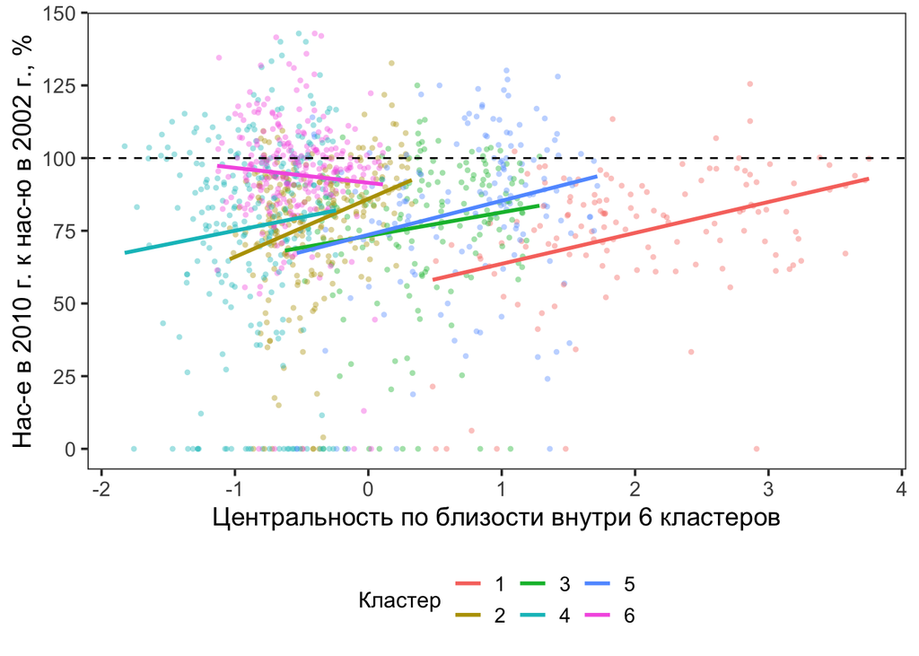

**Betweenness Centrality (6 clusters) vs Population Dynamics**

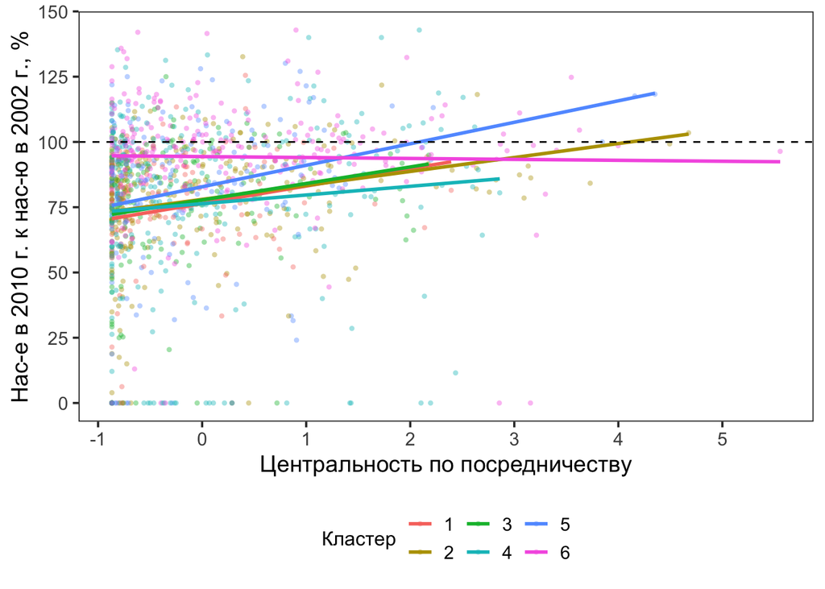

В обоих случаях из общей картины выбивается 6 кластер - тот самый, который вокруг Тюмени. В какой-то степени мы это учли, когда ввели случайные эффекты в модель. Тем не менее, я думаю, что если его вообще убрать из модели, effect size будет сильнее. Можно вытащить этот график и сделать вывод, что сетевые факторы хорошо работают за пределами пригородной зоны (агломерации). Внутри влияние большого города перевешивает все остальное.

### 3. Диагностика

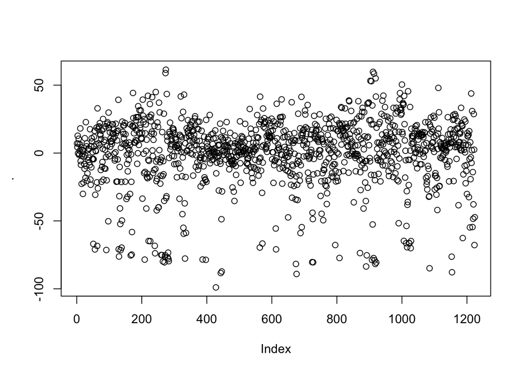

```r
# Check for homoroscedasticity of residuals
resid(model1) %>% plot()
```

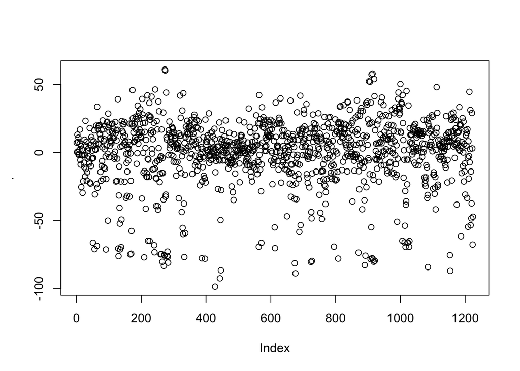

```r
resid(model2) %>% plot()
```

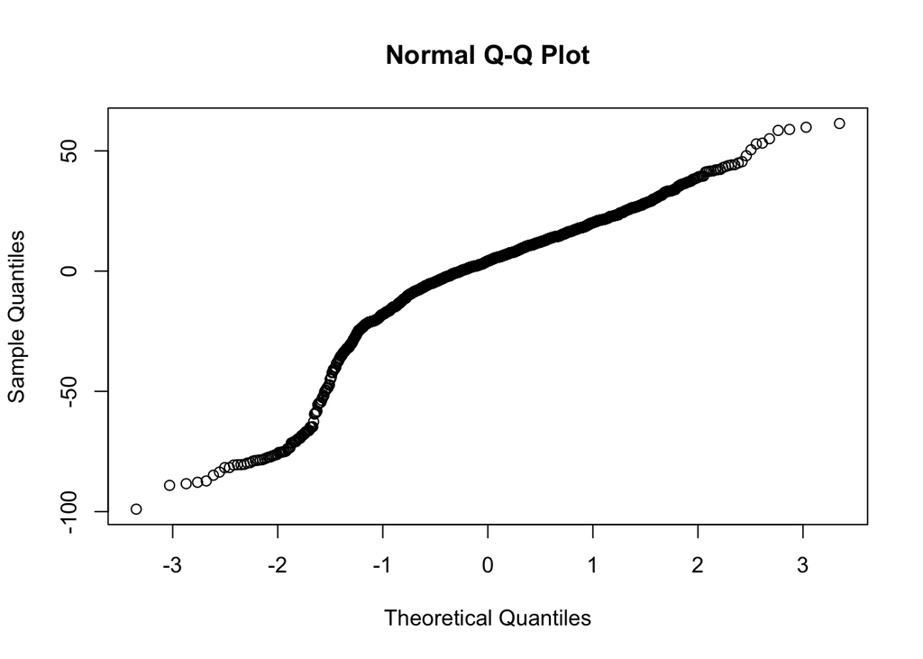

```r
# Distribution of residuals
resid(model1) %>% qqnorm()
```

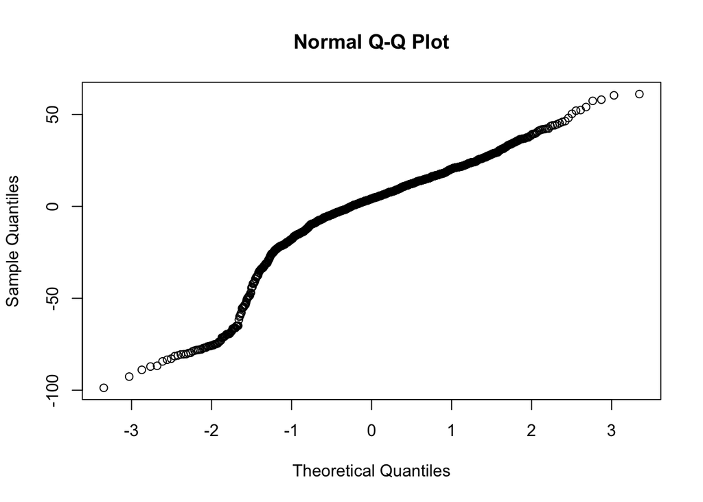

```r
resid(model2) %>% qqnorm()
```